# Prediction and Model Selection

Dr. Lucy D’Agostino McGowan

## Why Prediction Matters

In regression analysis, we often care about:

1. **Prediction accuracy** - how well does our model predict new observations?
2. **Model selection** - which predictors should we include?
3. **Generalization** - will our model work on future data?

# Prediction with OLS

## The Prediction Problem

We fit a model on our data and get $\hat{\beta}$

**Question:** How well will this model predict a *new* observation $y_{\text{new}}$ at $x_{\text{new}}$?

## Two Types of Predictions

**Fitted values:** Predictions for observations *in our dataset*

$$\hat{y}_i = x_i^T\hat{\beta}$$

## Two Types of Predictions

**Out-of-sample predictions:** Predictions for *new* observations

$$\hat{y}_{\text{new}} = x_{\text{new}}^T\hat{\beta}$$

## Prediction Error

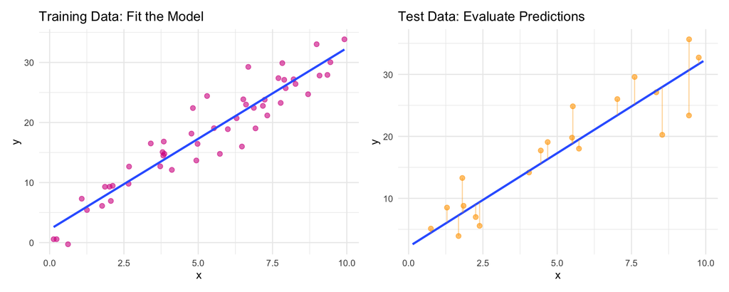

**Goal:** Minimize prediction error on *new* data, not just training data!

# Cross-Validation

## The Problem with Training Error

**Training error** (in-sample):
$$\text{MSE}_{\text{train}} = \frac{1}{n}\sum_{i=1}^n (y_i - \hat{y}_i)^2$$

**Problem:** Always decreases when we add predictors, even useless ones!

**Solution:** Estimate error on data the model hasn’t seen

## Leave-One-Out Cross-Validation (LOOCV)

**Idea:** For each observation $i$:

1. Remove observation $i$ from the dataset
2. Fit model on remaining $n-1$ observations
3. Predict the removed observation
4. Calculate prediction error

## Leave-One-Out Cross-Validation (LOOCV)

$$\text{CV} = \frac{1}{n}\sum_{i=1}^n (y_i - \hat{y}_{-i})^2$$

where $\hat{y}_{-i}$ is the prediction for $y_i$ using all data *except* observation $i$

## LOOCV: Visual Intuition

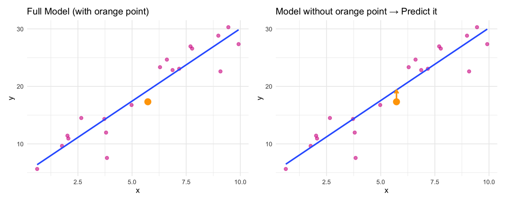

## LOOCV Seems Expensive!

**Problem:** LOOCV requires fitting the model $n$ times

For $n = 1000$ observations, we need to fit 1000 models!

**Good news:** There’s a shortcut using the hat matrix!

## The Hat Matrix

Remember that fitted values are:
$$\hat{y} = X\hat{\beta} = X(X^TX)^{-1}X^Ty = Hy$$

$$H = X(X^TX)^{-1}X^T$$

is called the **hat matrix** because it puts a “hat” on $y$

## Leverage: The Diagonal of $H$

The diagonal elements $h_{ii}$ are called **leverages**

$$\hat{y}_i = \sum_{j=1}^n h_{ij}y_j = h_{ii}y_i + \sum_{j \neq i}h_{ij}y_j$$

**Interpretation:** $h_{ii}$ measures how much $y_i$ influences its own prediction

## The LOOCV Shortcut

**Fun fact:** We don’t need to refit the model $n$ times!

$$\text{CV} = \frac{1}{n}\sum_{i=1}^n \left(\frac{y_i - \hat{y}_i}{1 - h_{ii}}\right)^2$$

This is exact LOOCV computed from a **single** model fit!

**Intuition:** The term $\frac{1}{1-h_{ii}}$ inflates residuals for high-leverage points

## LOOCV Formula Derivation

When we remove observation $i$, the prediction error is:

$$y_i - \hat{y}_{-i} = \frac{y_i - \hat{y}_i}{1 - h_{ii}}$$

**Why?** The fitted value $\hat{y}_i$ uses $y_i$ with weight $h_{ii}$

When we remove $y_i$, we need to account for its influence

## Computing LOOCV in R

```r
set.seed(1)
n <- 50
x <- runif(n, 0, 10)
y <- x + rnorm(n)

model <- lm(y ~ x)

# Get hat values (leverages)
h <- hatvalues(model)

# Get residuals
resid <- residuals(model)

# LOOCV using the shortcut formula
cv_error <- mean((resid / (1 - h))^2)

cv_error
```

```
[1] 0.8909796
```

## LOOCV for Model Selection

I generated data with a quadratic relationship and then fit increasingly flexible models.

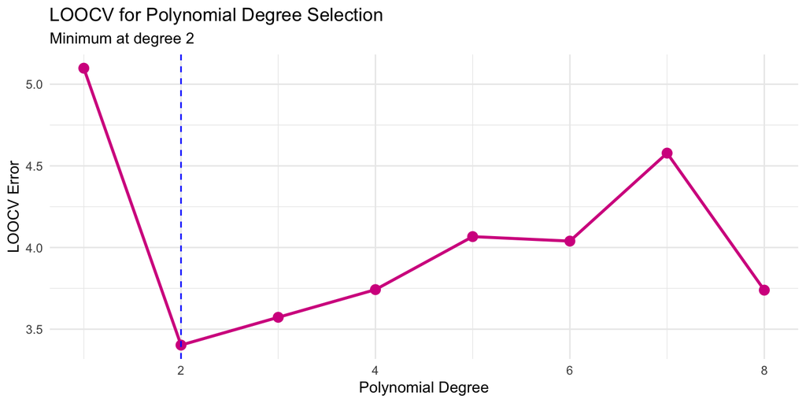

# Information Criteria

## Akaike Information Criterion (AIC)

**Idea:** Penalize model complexity

$$\text{AIC} = n\log(\text{MSE}) + 2p+\underbrace{n+n\log(2\pi)}_{C}$$

where $p$ is the number of parameters (including intercept)

## Akaike Information Criterion (AIC)

**Interpretation:**

- First term: fit to the data (want small MSE)
- Second term: penalty for complexity (want small $p$)

**Lower AIC is better**

## Connection Between AIC and LOOCV

**Fun fact:** AIC is asymptotically equivalent to LOOCV!

**Implication:** Choosing the model with smallest AIC is approximately the same as choosing the model with smallest LOOCV error

## Computing AIC in R

```r
# Using quadratic data from before
model1 <- lm(y ~ x)
model2 <- lm(y ~ poly(x, 2))
model3 <- lm(y ~ poly(x, 3))

aic_values <- c(AIC(model1), AIC(model2), AIC(model3))

data.frame(
  model = c("Linear", "Quadratic", "Cubic"),
  AIC = round(aic_values, 2)
)
```

```
      model    AIC
1    Linear 358.23
2 Quadratic 325.19
3     Cubic 327.11
```

## AIC for Model Selection

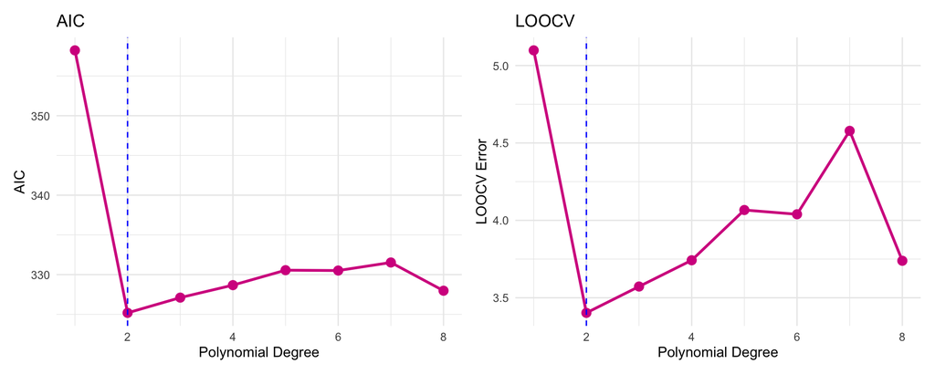

Notice: AIC and LOOCV select the same model (degree 2)!

# Other Model Selection Criteria

## Adjusted R²

**Problem with $R^2$:** Always increases when we add predictors

$$R^2 = 1 - \frac{\text{SSE}}{\text{TSS}}$$

## Adjusted R²

**Solution:** Penalize for number of predictors

$$R^2_{\text{adj}} = 1 - \frac{\text{SSE}/(n-p)}{\text{TSS}/(n-1)}$$

**Higher is better** (unlike AIC where lower is better)

## Adjusted R²: Intuition

Adjusted R² uses **unbiased estimates** of variance:

- $\text{SSE}/(n-p)$ is unbiased for $\sigma^2$
- $\text{TSS}/(n-1)$ is unbiased for variance of $y$

## Adjusted R²: Intuition

Adding a useless predictor:

- Decreases SSE slightly
- Increases $p$ by 1
- Denominator $n-p$ gets smaller
- Net effect can decrease $R^2_{\text{adj}}$

## Comparing Criteria

```
             AIC Adj_R2 LOOCV
Degree 1 358.228  0.570 5.098
Degree 2 325.187  0.719 3.403
Degree 3 327.106  0.715 3.573
Degree 5 330.560  0.710 4.067
```

## Mallows’ $C_p$

Another criterion for model selection:

$$C_p = \frac{\text{SSE}}{\hat{\sigma}^2} - n + 2p$$

where $\hat{\sigma}^2$ is estimated from the largest model considered

**Interpretation:** Estimates prediction error, similar to AIC

## All Criteria Together

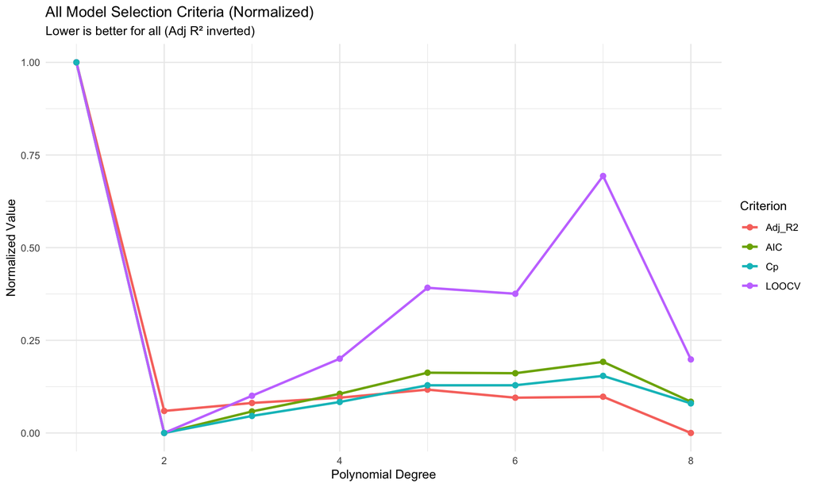

# Prediction Intervals

## Point Predictions vs Intervals

So far: point prediction $\hat{y}_{\text{new}} = x_{\text{new}}^T\hat{\beta}$

**Problem:** This gives no sense of uncertainty!

**Solution:** Construct an interval that contains $y_{\text{new}}$ with probability $1-\alpha$

## Two Types of Intervals

**Confidence interval for $E[y_{\text{new}}]$:**

- Uncertainty in estimating the *mean* response
- What is the average $y$ at this $x$?

## Two Types of Intervals

**Prediction interval for $y_{\text{new}}$:**

- Uncertainty in predicting a *single* new observation
- What will the next $y$ be at this $x$?

**Prediction intervals are always wider!**

## Sources of Uncertainty

**For confidence intervals:**
$$\text{Var}(\hat{y}_{\text{new}}) = \sigma^2 x_{\text{new}}^T(X^TX)^{-1}x_{\text{new}}$$

## Sources of Uncertainty

**For prediction intervals:**
$$\text{Var}(y_{\text{new}} - \hat{y}_{\text{new}}) = \sigma^2\left(1 + x_{\text{new}}^T(X^TX)^{-1}x_{\text{new}}\right)$$

The “+1” accounts for the inherent randomness of $y_{\text{new}}$

## Prediction Interval Formula

$$\hat{y}_{\text{new}} \pm t_{\alpha/2, n-p} \cdot \hat{\sigma}\sqrt{1 + x_{\text{new}}^T(X^TX)^{-1}x_{\text{new}}}$$

where:

- $t_{\alpha/2, n-p}$ is the t-distribution critical value
- $\hat{\sigma}$ is the estimated standard deviation of residuals

## Visualization: Confidence vs Prediction

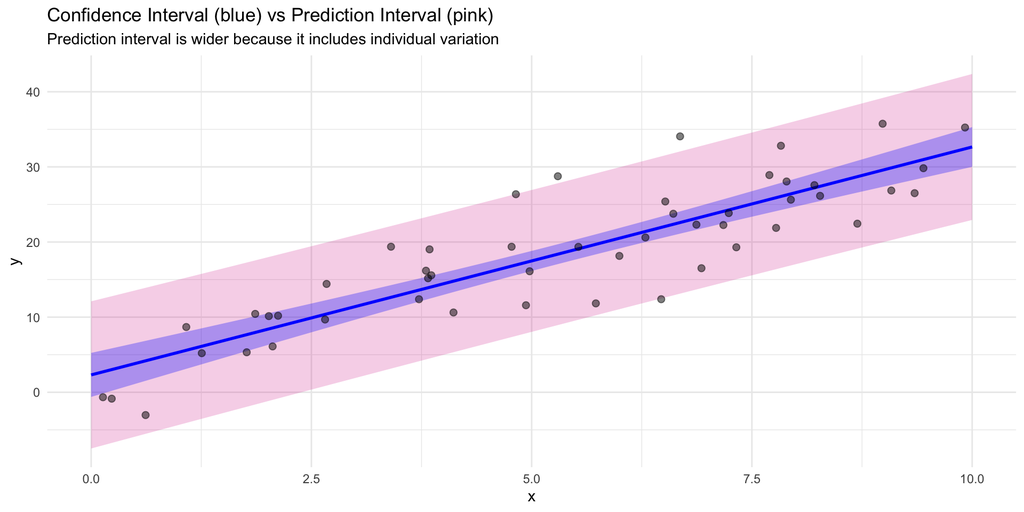

## Computing Intervals in R

```r
# Fit model
model <- lm(y ~ x)

# New x value
x_new <- data.frame(x = 5)

# Confidence interval for mean
conf_int <- predict(model, newdata = x_new,
                    interval = "confidence", level = 0.95)

# Prediction interval for new observation
pred_int <- predict(model, newdata = x_new,
                    interval = "prediction", level = 0.95)

# Compare
rbind(
  Confidence = conf_int,
  Prediction = pred_int
)
```

```
       fit       lwr      upr
1 17.48305 16.151581 18.81453
1 17.48305  8.041862 26.92425
```

# Ridge Regression

## The Problem: Multicollinearity

**What happens when predictors are highly correlated?**

- OLS estimates $\hat{\beta}$ become unstable
- Small changes in data → large changes in coefficients
- Variance of $\hat{\beta}$ is large
- Predictions can be unreliable

## Visualizing Multicollinearity

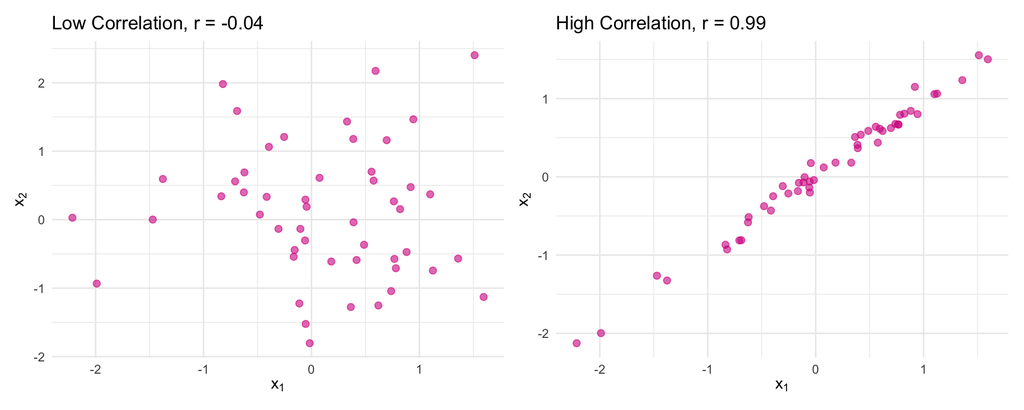

## The Variance Inflation Factor

**Quantifies multicollinearity:**

$$\text{VIF}_j = \frac{1}{1 - R^2_j}$$

where $R^2_j$ is from regressing $x_j$ on all other predictors

## Ridge Regression: The Idea

**Trade bias for reduced variance**

Instead of minimizing SSE: $\min_{\beta} \sum_{i=1}^n (y_i - x_i^T\beta)^2$

Ridge regression adds a penalty: $\min_{\beta} \sum_{i=1}^n (y_i - x_i^T\beta)^2 + \lambda\sum_{j=1}^p \beta_j^2$

## Ridge Regression: The Idea

**$\lambda \geq 0$ is the tuning parameter:**

- $\lambda = 0$: ordinary least squares
- $\lambda > 0$: shrinks coefficients toward zero
- $\lambda \to \infty$: all coefficients → 0

## Why Penalize the Coefficients?

**Large coefficients indicate:**

- Model is fitting noise
- Overly sensitive to small changes
- High variance in predictions

## Why Penalize the Coefficients?

**Penalizing $\sum \beta_j^2$ encourages:**

- Smaller, more stable coefficients
- Reduced variance
- Better prediction (despite bias)

## Ridge Solution

The ridge estimator has a closed form: $\hat{\beta}_{\text{ridge}} = (X^TX + \lambda I)^{-1}X^Ty$

Compare to OLS: $\hat{\beta}_{\text{OLS}} = (X^TX)^{-1}X^Ty$

**Key difference:** Adding $\lambda I$ to $X^TX$ ensures the matrix is invertible even when $X^TX$ is singular!

## Standardization is Critical

**Problem:** Penalty depends on scale of predictors

If $x_1$ is in dollars and $x_2$ is in thousands of dollars, their coefficients are penalized differently

**Solution:** Standardize predictors before applying ridge regression $\tilde{x}_{ij} = \frac{x_{ij} - \bar{x}_j}{s_j}$

**Note:** Usually don’t penalize the intercept

## Bias-Variance Tradeoff

[figure not shown]

## Choosing Lambda: Cross-Validation

**How do we choose $\lambda$?**

Use cross-validation to find $\lambda$ that minimizes prediction error!

## Ridge Regression with CV

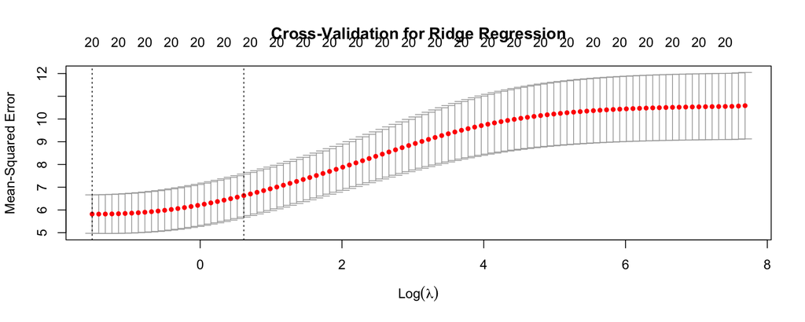

```r
library(glmnet)

# Use previous data
# alpha = 0 means ridge (alpha = 1 would be lasso)
ridge_cv <- cv.glmnet(X_scaled, y, alpha = 0)

# Plot CV error
plot(ridge_cv, main = "Cross-Validation for Ridge Regression")
```

## LOOCV Shortcut for Ridge

**Good news:** The hat matrix trick works for ridge too!

For ridge regression with penalty $\lambda$, the hat matrix is:

$H_{\lambda} = X(X^TX + \lambda I)^{-1}X^T$

**LOOCV formula:**

$\text{CV}(\lambda) = \frac{1}{n}\sum_{i=1}^n \left(\frac{y_i - \hat{y}_i(\lambda)}{1 - h_{ii}(\lambda)}\right)^2$

where $h_{ii}(\lambda)$ is the $i$-th diagonal of $H_{\lambda}$

**Just like OLS**, but now everything depends on $\lambda$!

## Computing LOOCV for Ridge

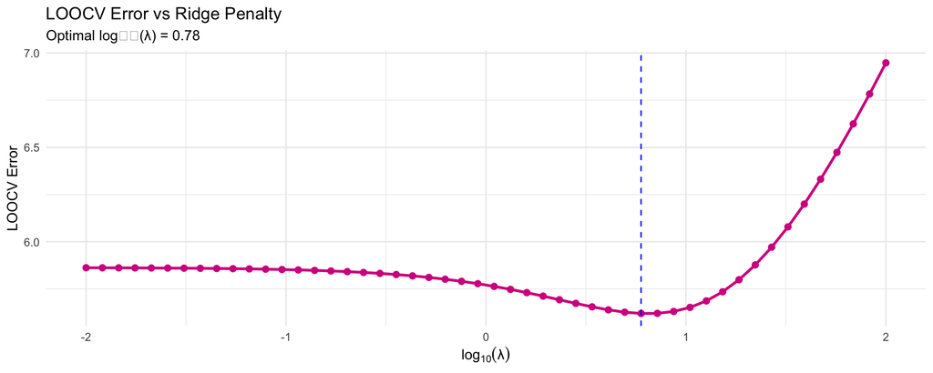

```r
# Compute LOOCV manually for a grid of lambdas
lambdas <- 10^seq(2, -2, length.out = 50)
loocv_errors <- numeric(length(lambdas))

for (i in seq_along(lambdas)) {
  lambda <- lambdas[i]

  # Ridge hat matrix
  H_lambda <- X_scaled %*% solve(t(X_scaled) %*% X_scaled + lambda * diag(p)) %*% t(X_scaled)

  # Ridge predictions
  y_hat <- H_lambda %*% y

  # LOOCV using shortcut formula
  h_diag <- diag(H_lambda)
  loocv_errors[i] <- mean(((y - y_hat) / (1 - h_diag))^2)
}

# Plot
ggplot(data.frame(lambda = lambdas, loocv = loocv_errors),
       aes(x = log10(lambda), y = loocv)) +
  geom_line(color = "#d5008f", linewidth = 1) +
  geom_point(color = "#d5008f", size = 2) +
  geom_vline(xintercept = log10(lambdas[which.min(loocv_errors)]),
             linetype = "dashed", color = "blue") +
  labs(title = "LOOCV Error vs Ridge Penalty",
       subtitle = paste("Optimal log₁₀(λ) =",
                       round(log10(lambdas[which.min(loocv_errors)]), 2)),
       x = expression(log[10](λ)),
       y = "LOOCV Error") +
  theme_minimal()
```

## LOOCV vs K-Fold CV for Ridge

**LOOCV advantages:** - Exact formula using hat matrix - No randomness in the split - Maximum use of training data

**K-fold CV (what `cv.glmnet` uses):** - Computationally faster for large $n$ - Can be more stable (less variance) - Default is 10-fold

**In practice:** Both work well, k-fold is more common

## Ridge vs OLS Coefficients

```r
# OLS coefficients
beta_ols <- coef(lm(y ~ X_scaled))[-1]  # Remove intercept

# Ridge coefficients at optimal lambda
beta_ridge <- as.vector(coef(ridge_cv, s = "lambda.min"))[-1]

# Compare first 8 coefficients
comparison <- data.frame(
  Predictor = paste("x", 1:8, sep = ""),
  True = beta_true[1:8],
  OLS = round(beta_ols[1:8], 3),
  Ridge = round(beta_ridge[1:8], 3)
)

comparison
```

```
          Predictor True    OLS  Ridge
X_scaled1        x1  3.0  2.488  2.164
X_scaled2        x2 -2.0 -1.558 -1.044
X_scaled3        x3  1.5  1.889  1.352
X_scaled4        x4 -1.0 -0.991 -0.564
X_scaled5        x5  0.5  0.571  0.426
X_scaled6        x6  0.0  0.070  0.077
X_scaled7        x7  0.0  0.410  0.324
X_scaled8        x8  0.0 -0.621 -0.491
```

## When Does Ridge Help?

**Ridge regression is most useful when:**

1. Predictors are highly correlated
2. Number of predictors is large relative to sample size
3. You care more about prediction than interpretation
4. OLS estimates are unstable

## Prediction Performance Comparison

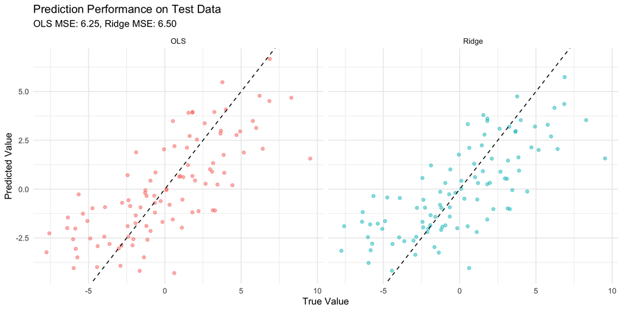

## Effective Degrees of Freedom

**Question:** How many parameters does ridge regression use?

**Naïve answer:** Still $p$ predictors… but they’re shrunk!

**Correct answer:** Effective degrees of freedom

$\text{df}(\lambda) = \text{tr}(H_{\lambda})$

where $H_{\lambda} = X(X^TX + \lambda I)^{-1}X^T$ is the ridge hat matrix

**Properties:**

- $\lambda = 0$: $\text{df} = p$ (OLS)
- $\lambda \to \infty$: $\text{df} \to 0$ (no predictors).
- Larger $\lambda$ → fewer effective parameters

## The Ridge Constraint Region

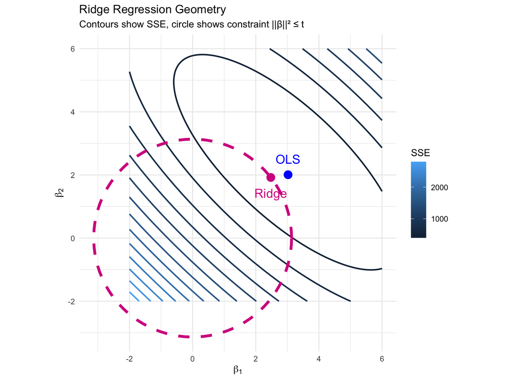

**Ridge solution:** Point where SSE contour touches the constraint circle